# Miami-Dade County COVID-19 Trajectory

Roy Williams, Gabriel J. Odom, Zoran Bursac, and Mary Jo Trepka

21 June 2020

# Introduction

Public understanding of science is critical in times of crisis. The following analysis was conducted to examine the trajectory of COVID-19 in Miami-Dade County. For phased reopening, The White House has set guidelines for local municipalities in their “Opening Up American Again” report. In the report, it is highly suggested that:

1. Local areas show a downward trajectory in the number of positive cases as a percent of total tests over a two-week period, and
2. Local hospitals have capacity to handle all patients without crisis care.

The analysis begins by looking at the number of new positive cases each day and the number of total tests performed each day. The figures are presented together because **as there is more testing, there are likely to be more positive test results**. Therefore, the proportion of positive cases is also calculated. Given either a flat or increasing number of tests performed, **the proportion of positive cases is the key metric to be used when looking at epidemic trajectory**. It is recommended that this proportion not exceed 5%.

Finally, to ensure hospitals can meet demand without crisis care, the COVID-19 positive hospitalization census, COVID-19 positive ICU census, and COVID-19 positive ventilation census is plotted over time. Census refers to the number of COVID-19 positive patients in the hospital, ICU, and on ventilators, respectively, on a given day.

# COVID-19 Test Counts and Proportions

## Full Data

This is a table of the most recent data we have available. We include data sources at the end of the document.

| Date | Positive | Negative | Total | PropPositive |
| --- | --- | --- | --- | --- |
| 2-Apr | 544 | 2413 | 2957 | 18.3970240 |
| 3-Apr | 625 | 1878 | 2503 | 24.9700360 |
| 4-Apr | 531 | 2521 | 3052 | 17.3984273 |
| 5-Apr | 311 | 1260 | 1571 | 19.7963081 |
| 6-Apr | 556 | 2309 | 2865 | 19.4066318 |
| 7-Apr | 493 | 1990 | 2483 | 19.8550141 |
| 8-Apr | 488 | 1113 | 1601 | 30.4809494 |
| 9-Apr | 435 | 2636 | 3071 | 14.1647672 |
| 10-Apr | 542 | 2505 | 3047 | 17.7879882 |
| 11-Apr | 563 | 2732 | 3295 | 17.0864947 |
| 12-Apr | 364 | 1614 | 1978 | 18.4024267 |
| 13-Apr | 477 | 2267 | 2744 | 17.3833819 |
| 14-Apr | 364 | 1663 | 2027 | 17.9575728 |
| 15-Apr | 438 | 2392 | 2830 | 15.4770318 |
| 16-Apr | 536 | 2767 | 3303 | 16.2276718 |
| 17-Apr | 519 | 2901 | 3420 | 15.1754386 |
| 18-Apr | 296 | 1509 | 1805 | 16.3988920 |
| 19-Apr | 465 | 2690 | 3155 | 14.7385103 |
| 20-Apr | 413 | 3232 | 3645 | 11.3305898 |
| 21-Apr | 577 | 4230 | 4807 | 12.0033285 |
| 22-Apr | 465 | 2701 | 3166 | 14.6873026 |
| 23-Apr | 619 | 3647 | 4266 | 14.5100797 |
| 24-Apr | 552 | 2852 | 3404 | 16.2162162 |
| 25-Apr | 564 | 4136 | 4700 | 12.0000000 |
| 26-Apr | 384 | 2576 | 2960 | 12.9729730 |
| 27-Apr | 446 | 2789 | 3235 | 13.7867079 |
| 28-Apr | 213 | 1333 | 1546 | 13.7774903 |
| 29-Apr | 309 | 1704 | 2013 | 15.3502235 |
| 30-Apr | 333 | 3724 | 4057 | 8.2080355 |
| 1-May | 250 | 3616 | 3866 | 6.4666322 |

[output cut: 51 more lines]

The data above show for each day since April 2: the number of positive COVID-19 tests, the number of negative COVID-19 tests, and the proportion of positive COVID-19 tests to total COVID-19 tests.

## Total COVID-19 Tests by Day

We see the following pattern for the count of total tests over the past two months (shown on a log scale):

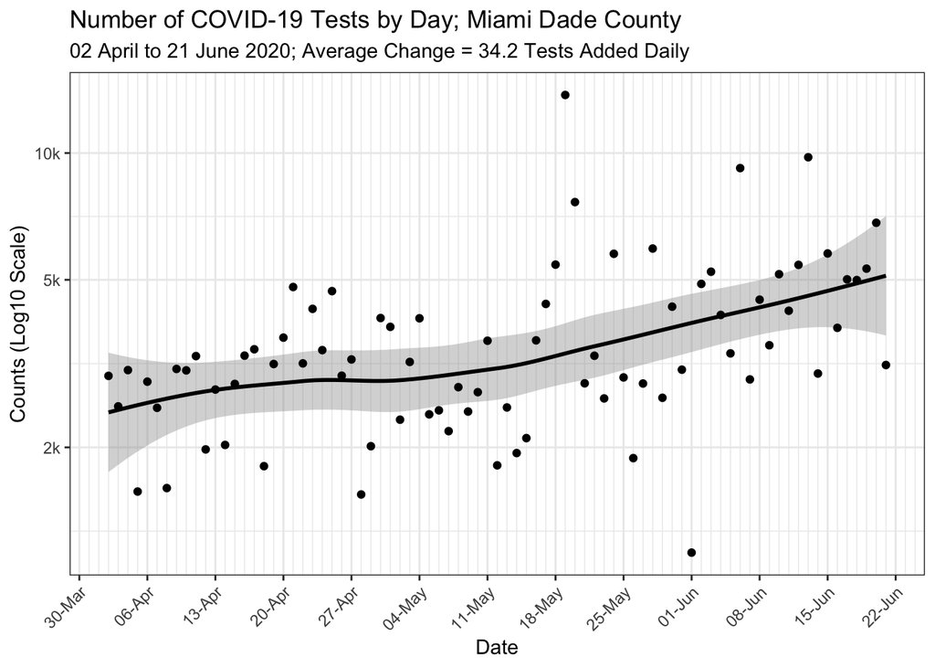

## Positive COVID-19 Tests by Day

We see the following pattern for the count of positive tests over the past two months:

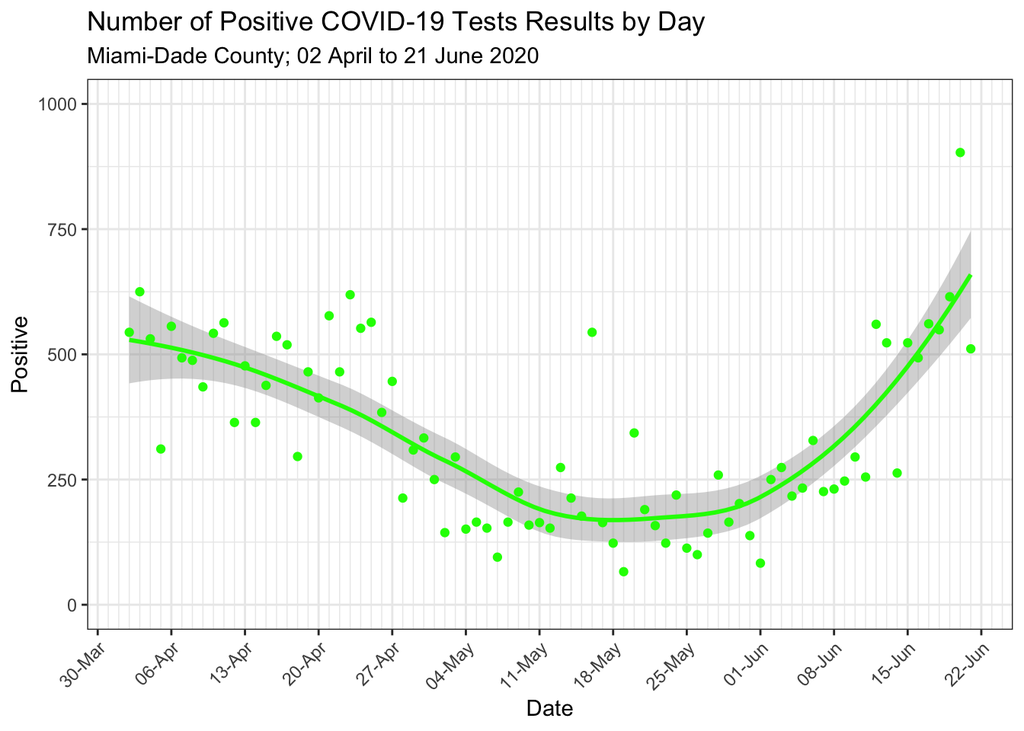

### Positive COVID-19 Tests within the Past Two Weeks

In addition to the overall trend of positive COVID-19 tests shown above, we also show an enhanced view of the last two weeks, highlighting the stark increase in positive cases during this period of time.

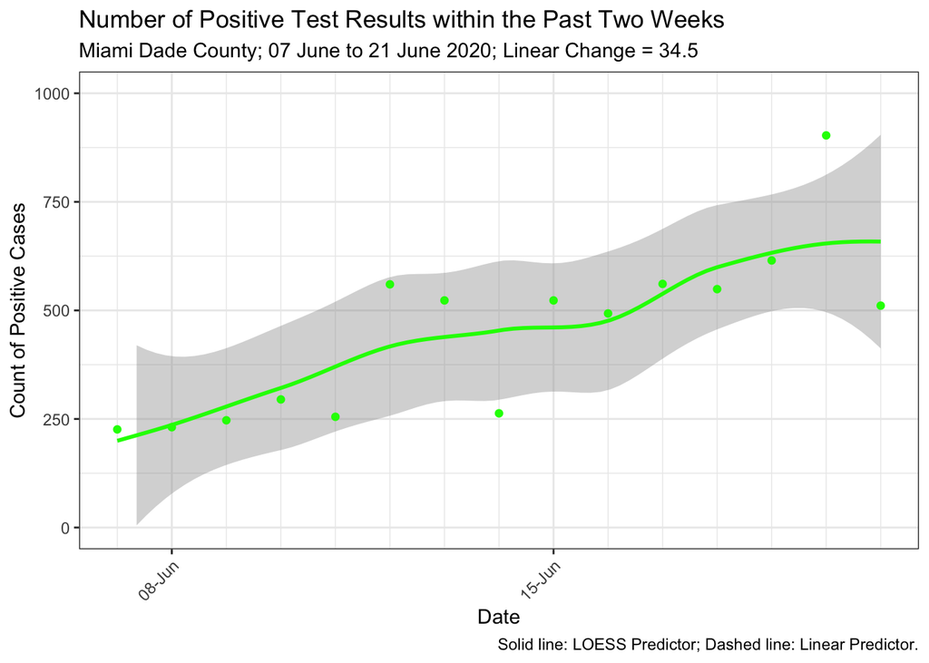

## Proportion of Positive Cases within Past Two Weeks

The proportion of positive COVID-19 tests for the past two weeks is:

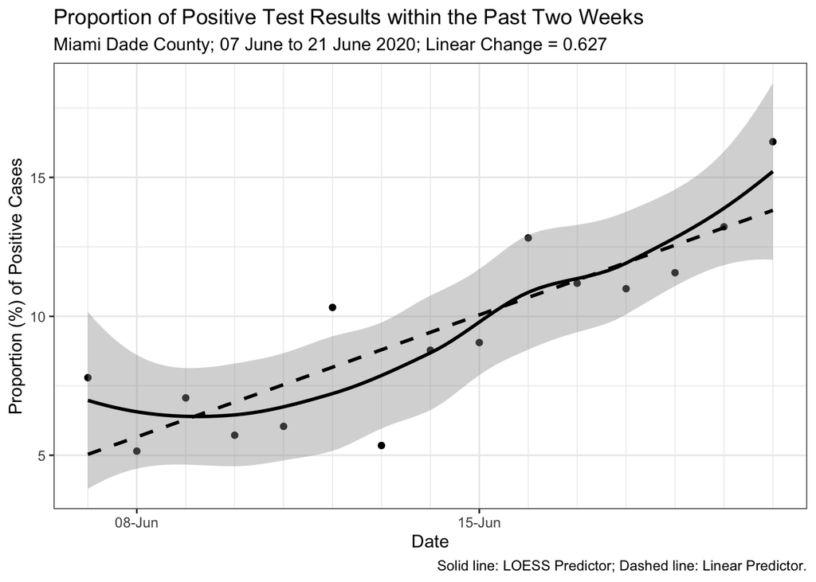

During the 14-day period from 07 June to 21 June, there was a **significant increase** in the proportion of positive COVID-19 cases reported in Miami-Dade County. This increase was even greater during the last week. During the previous week, the proportion of positive cases was increasing close to 1% per day. Given a flat or increasing number of tests performed, the proportion of positive tests obtained is the **key metric** for examining COVID-19 trajectory. **The percentage of positive test results obtained over the past two-weeks has exceeded the 5% positive threshold recommended by the World Health Organization (WHO) for reopening.**

## Proportion of Positive COVID-19 Tests by Day

These are the proportions of positive COVID-19 tests for the since the start of April:

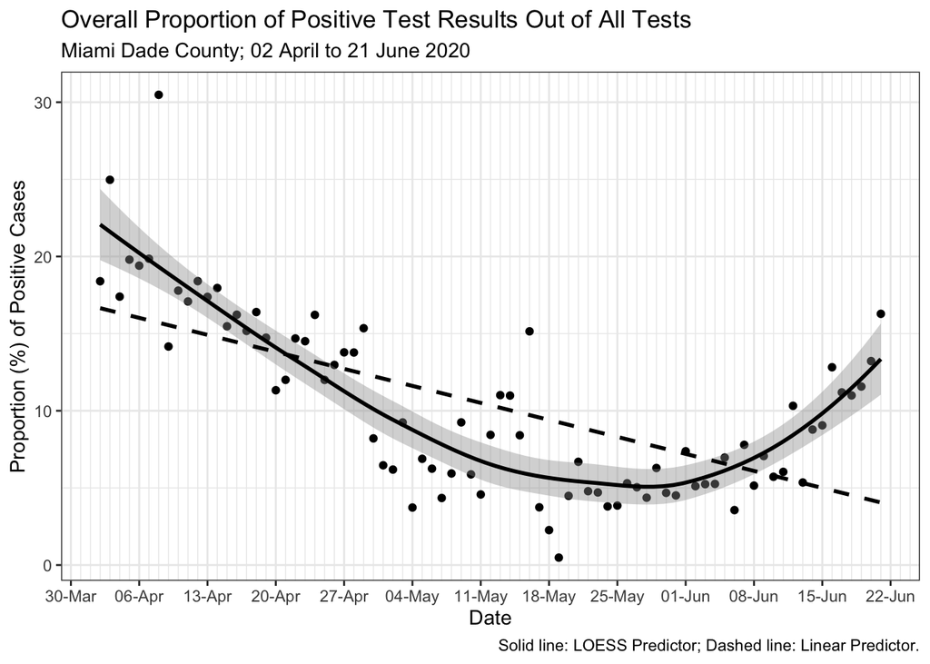

Overall, the proportion of positive test results out of all tests **decreased significantly** from over 20% in April to the current proportion of about 12% over the past week. This is function of test availability and the population being tested. However, since the county has begun reopening, the proportion of positive tests is no longer decreasing over time. Given a flat or increasing number of tests performed, an increase in the proportion of positive tests obtained points to evidence of increased COVID-19 community spread in Miami-Dade county.